# Consumo de alcohol en estudiantes

Con este estudio, el objetivo que pretendemos es analizar el consumo de alcohol en estudiantes y su relación con otras variables. Para ello, vamos a utilizar un dataset que contiene información sobre estudiantes de dos escuelas portuguesas, incluyendo datos sobre su consumo de alcohol, características personales, familiares y académicas.

## Pasos KDD

### Integración

A la hora de observar los dataset, tenemos un dataset para la asignatura de matemáticas y otro para la asignatura de portugués. Ambos datasets tienen la misma estructura y se pueden unir en un único dataset. Sin embargo, en este caso, vamos a trabajar con el dataset de portugués.

Esto se debe a que hay 382 instancias que pertenecen a ambas asignaturas, y no queremos duplicar la información. Además, el dataset de portugués tiene más instancias que el de matemáticas, por lo que nos aportará más información. El hecho de seleccionar el dataset de portugués solamente excluiría a 13 instancias del dataset de matemáticas, por lo que no perderíamos mucha información con esta decisión.

Una de las alternativas que estudiamos fue unir ambos datasets y fusionar las instancias duplicadas, calculando la media de las notas de ambas asignaturas para cada período. Sin embargo, esto implicaría una pérdida de información, ya que no podríamos analizar las diferencias entre ambas.

```r
library(dplyr)
# Lectura de dataset
df=read.table("data/student-por.csv",sep=",",header=TRUE)

# Convertir columnas necesarias a factor
cols_to_factor <- c("school", "sex", "address", "famsize", "Pstatus", "Medu", "Fedu", "Mjob",
                    "Fjob", "reason", "guardian", "traveltime", "studytime" ,"famrel"
                    , "freetime", "goout", "health")

df[cols_to_factor] <- lapply(df[cols_to_factor], as.factor)

cols_to_boolean <- c("schoolsup", "famsup", "paid", "activities", "nursery", "higher", "internet", "romantic")

df[cols_to_boolean] <- lapply(df[cols_to_boolean], function(x) x == "yes")

df_long <- tidyr::pivot_longer(df, cols = c("Dalc", "Walc"), names_to = "period", values_to = "consumption")

print(nrow(df))
```

```
## [1] 649
```

```r
print(head(df))
```

```
##   school sex age address famsize Pstatus Medu Fedu     Mjob     Fjob     reason
## 1     GP   F  18       U     GT3       A    4    4  at_home  teacher     course
## 2     GP   F  17       U     GT3       T    1    1  at_home    other     course
## 3     GP   F  15       U     LE3       T    1    1  at_home    other      other
## 4     GP   F  15       U     GT3       T    4    2   health services       home
## 5     GP   F  16       U     GT3       T    3    3    other    other       home
## 6     GP   M  16       U     LE3       T    4    3 services    other reputation
##   guardian traveltime studytime failures schoolsup famsup  paid activities
## 1   mother          2         2        0      TRUE  FALSE FALSE      FALSE
## 2   father          1         2        0     FALSE   TRUE FALSE      FALSE
## 3   mother          1         2        0      TRUE  FALSE FALSE      FALSE
## 4   mother          1         3        0     FALSE   TRUE FALSE       TRUE
## 5   father          1         2        0     FALSE   TRUE FALSE      FALSE
## 6   mother          1         2        0     FALSE   TRUE FALSE       TRUE
##   nursery higher internet romantic famrel freetime goout Dalc Walc health
## 1    TRUE   TRUE    FALSE    FALSE      4        3     4    1    1      3
## 2   FALSE   TRUE     TRUE    FALSE      5        3     3    1    1      3
## 3    TRUE   TRUE     TRUE    FALSE      4        3     2    2    3      3
## 4    TRUE   TRUE     TRUE     TRUE      3        2     2    1    1      5
## 5    TRUE   TRUE    FALSE    FALSE      4        3     2    1    2      5
## 6    TRUE   TRUE     TRUE    FALSE      5        4     2    1    2      5
##   absences G1 G2 G3
## 1        4  0 11 11
## 2        2  9 11 11
## 3        6 12 13 12
## 4        0 14 14 14
## 5        0 11 13 13
## 6        6 12 12 13
```

```r
print(str(df))
```

```
## 'data.frame':    649 obs. of  33 variables:
##  $ school    : Factor w/ 2 levels "GP","MS": 1 1 1 1 1 1 1 1 1 1 ...
##  $ sex       : Factor w/ 2 levels "F","M": 1 1 1 1 1 2 2 1 2 2 ...
##  $ age       : int  18 17 15 15 16 16 16 17 15 15 ...
##  $ address   : Factor w/ 2 levels "R","U": 2 2 2 2 2 2 2 2 2 2 ...
##  $ famsize   : Factor w/ 2 levels "GT3","LE3": 1 1 2 1 1 2 2 1 2 1 ...
##  $ Pstatus   : Factor w/ 2 levels "A","T": 1 2 2 2 2 2 2 1 1 2 ...
##  $ Medu      : Factor w/ 5 levels "0","1","2","3",..: 5 2 2 5 4 5 3 5 4 4 ...
##  $ Fedu      : Factor w/ 5 levels "0","1","2","3",..: 5 2 2 3 4 4 3 5 3 5 ...
##  $ Mjob      : Factor w/ 5 levels "at_home","health",..: 1 1 1 2 3 4 3 3 4 3 ...
##  $ Fjob      : Factor w/ 5 levels "at_home","health",..: 5 3 3 4 3 3 3 5 3 3 ...
##  $ reason    : Factor w/ 4 levels "course","home",..: 1 1 3 2 2 4 2 2 2 2 ...
##  $ guardian  : Factor w/ 3 levels "father","mother",..: 2 1 2 2 1 2 2 2 2 2 ...
##  $ traveltime: Factor w/ 4 levels "1","2","3","4": 2 1 1 1 1 1 1 2 1 1 ...
##  $ studytime : Factor w/ 4 levels "1","2","3","4": 2 2 2 3 2 2 2 2 2 2 ...
```

[output cut: 20 more lines]

## Visualización

```r
library(ggplot2)
library(tidyr)
library(dplyr)
```

## Histograma de consumo de alcohol entre semana vs fin de semana

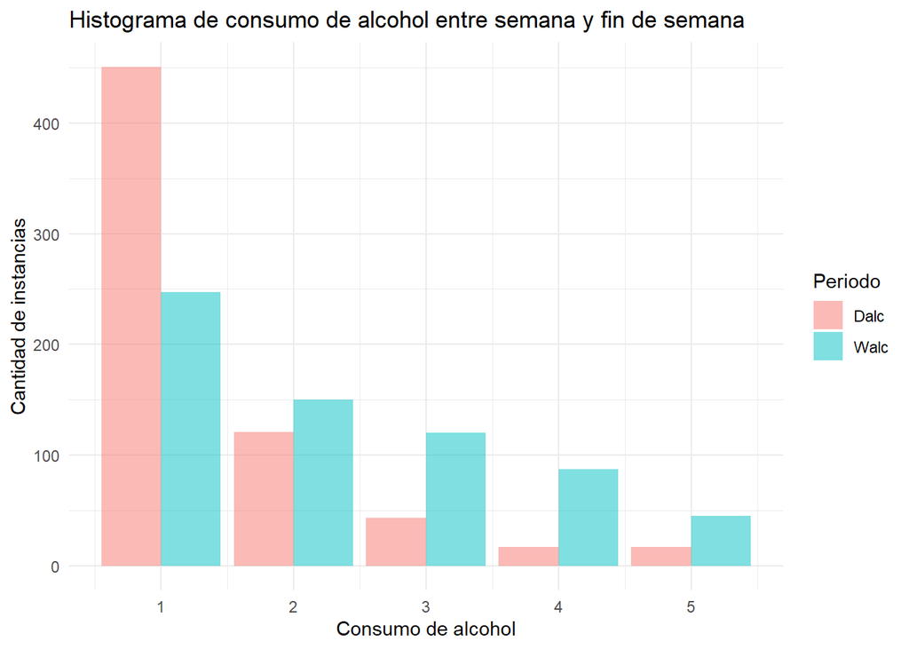

```r
ggplot() +
  geom_histogram(data = df_long, aes(x = consumption, fill = period), position = position_dodge(), stat = "count", alpha = 0.5, bins = 10) +
  labs(title = "Histograma de consumo de alcohol entre semana y fin de semana",
       x = "Consumo de alcohol",
       y = "Cantidad de instancias",
       fill = "Periodo") +
  theme_minimal()
```

## Gráfico de dispersión de consumo de alcohol entre semana y en fin de semana

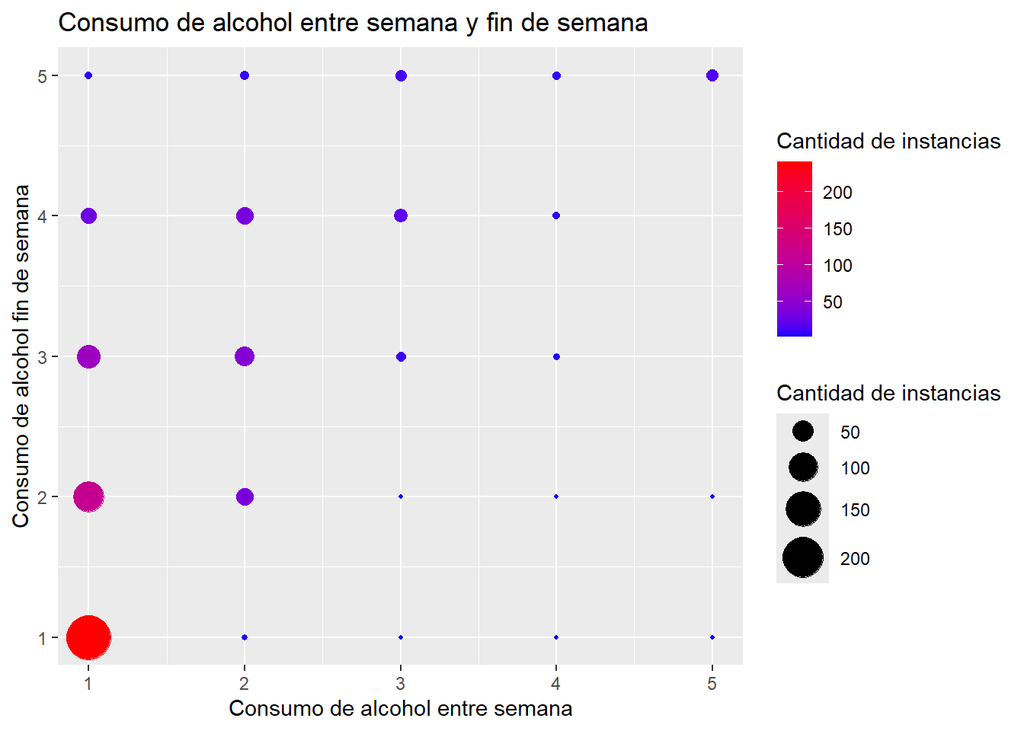

```r
ggplot(df, aes(x = Dalc, y = Walc)) +
  geom_count(aes(color = after_stat(n), size = after_stat(n))) +
  scale_size_area(max_size = 10) +
  scale_color_gradient(low = "blue", high = "red") +
  labs(title = "Consumo de alcohol entre semana y fin de semana",
       x = "Consumo de alcohol entre semana",
       y = "Consumo de alcohol fin de semana",
       size = "Cantidad de instancias",
       color = "Cantidad de instancias")
```

## Gráfico de tarta de la distribución conjunta de Dalc y Walc

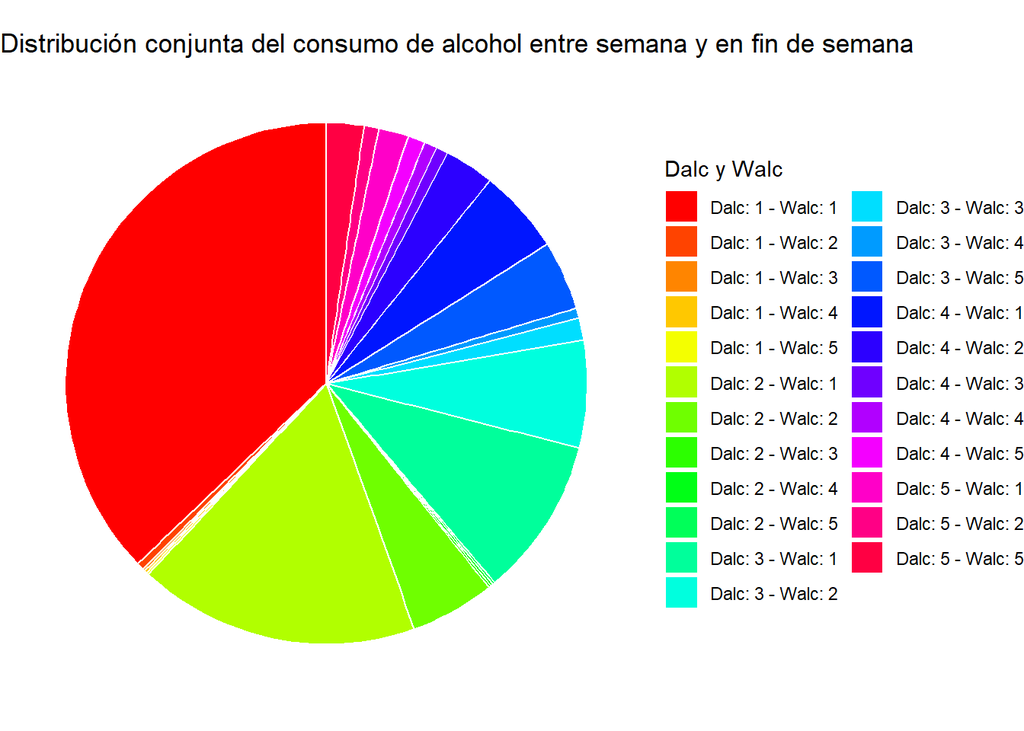

```r
df_count <- df %>%
  count(Dalc, Walc) %>%
  mutate(prop = n / sum(n))

ggplot(df_count, aes(x = "", y = prop, fill = interaction(Dalc, Walc))) +
  geom_bar(stat = "identity", width = 1, color = "white") +
  coord_polar("y") +
  scale_fill_manual(name = "Dalc y Walc",
                    labels = paste("Dalc:", df_count$Dalc, "- Walc:", df_count$Walc),
                    values = rainbow(nrow(df_count))) +
  labs(title = "Distribución conjunta del consumo de alcohol entre semana y en fin de semana",
       x = NULL, y = NULL) +
  theme_void()
```

## Media de consumo según la nota final

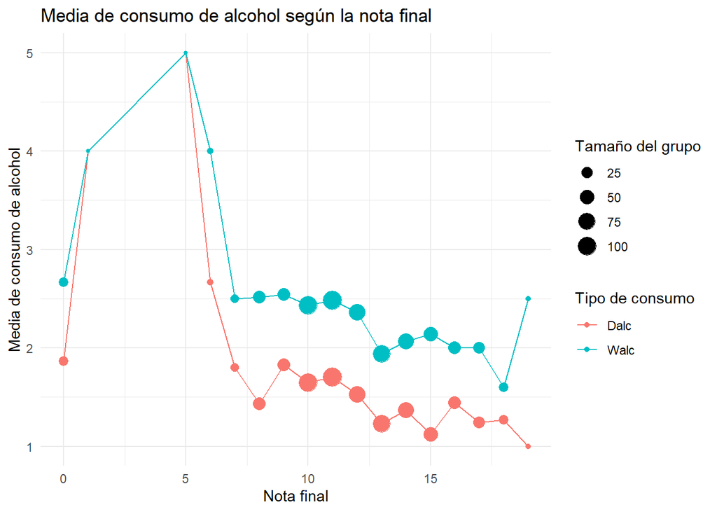

```r
df %>%
  filter(!is.na(G3) & !is.na(Dalc) & !is.na(Walc)) %>%
  group_by(G3) %>%
  summarise(mean_Dalc = mean(Dalc, na.rm = TRUE),
            mean_Walc = mean(Walc, na.rm = TRUE),
            count = n()) %>%
  ggplot(aes(x = G3)) +
  geom_point(aes(y = mean_Dalc, color = "Dalc", size = count)) +
  geom_line(aes(y = mean_Dalc, color = "Dalc")) +
  geom_point(aes(y = mean_Walc, color = "Walc", size = count)) +
  geom_line(aes(y = mean_Walc, color = "Walc")) +
  labs(title = "Media de consumo de alcohol según la nota final",
       x = "Nota final",
       y = "Media de consumo de alcohol",
       color = "Tipo de consumo",
       size = "Tamaño del grupo") +
  theme_minimal()
```

## Porcentaje de personas perteneciente a cada grupo de consumo según el sexo para Dalc y Walc

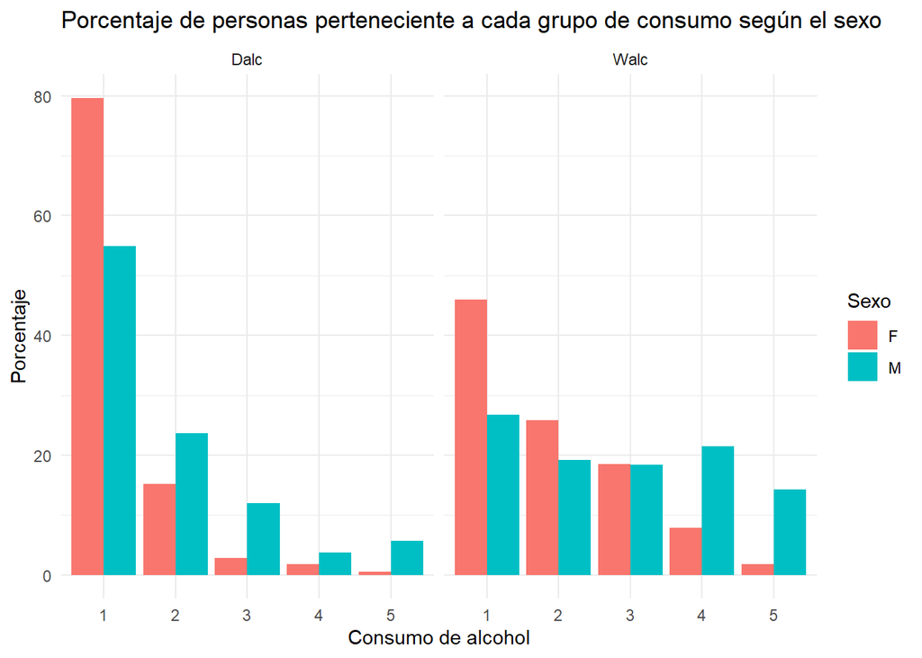

```r
df_long %>%
  group_by(sex, period, consumption) %>%
  summarise(count = n()) %>%
  group_by(sex, period) %>%
  mutate(percentage = count / sum(count) * 100) %>%
  ggplot(aes(x = factor(consumption), y = percentage, fill = sex)) +
  geom_bar(stat = "identity", position = "dodge") +
  facet_wrap(~period) +
  labs(title = "Porcentaje de personas perteneciente a cada grupo de consumo según el sexo",
       x = "Consumo de alcohol",
       y = "Porcentaje",
       fill = "Sexo") +
  theme_minimal()
```

## Gráfico de media de consumo de alcohol según si los padres están separados o no (entre semana vs fin de semana)

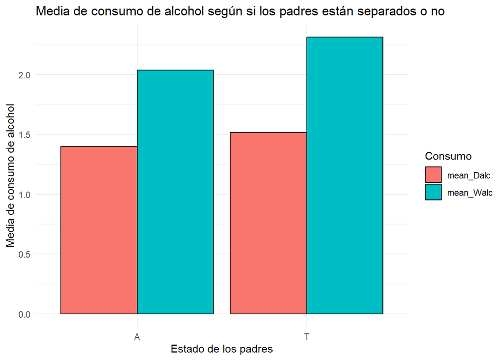

```r
df %>%
  group_by(Pstatus) %>%
  summarise(mean_Dalc = mean(Dalc), mean_Walc = mean(Walc)) %>%
  pivot_longer(cols = c(mean_Dalc, mean_Walc), names_to = "Consumo", values_to = "Media") %>%
  ggplot(aes(x = Pstatus, y = Media, fill = Consumo)) +
  geom_bar(stat = "identity", position = "dodge", color = "black") +
  labs(title = "Media de consumo de alcohol según si los padres están separados o no",
       x = "Estado de los padres",
       y = "Media de consumo de alcohol",
       fill = "Consumo") +
  theme_minimal()
```

## Gráfico de media de consumo de alcohol en función de las ausencias escolares (entre semana vs fin de semana)

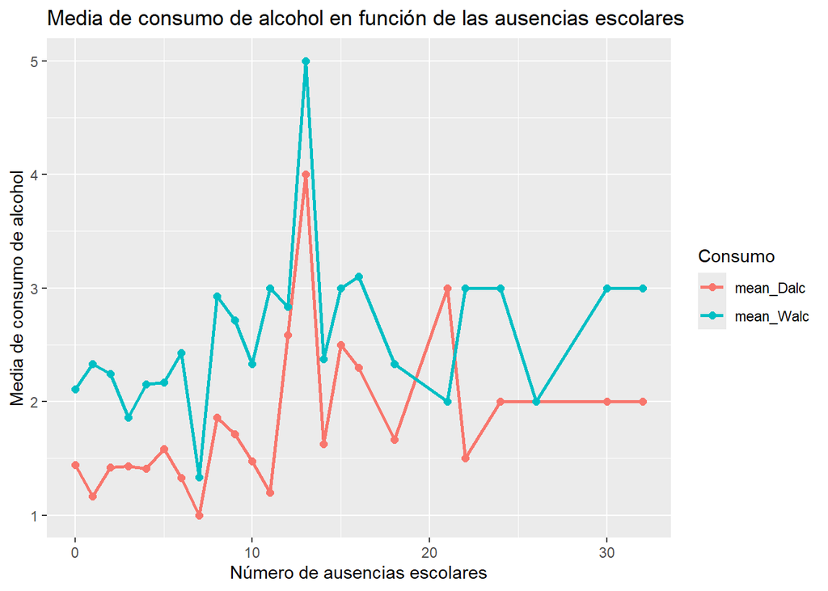

```r
df %>%
  group_by(absences) %>%
  summarise(mean_Dalc = mean(Dalc), mean_Walc = mean(Walc)) %>%
  pivot_longer(cols = c(mean_Dalc, mean_Walc), names_to = "Consumo", values_to = "Media") %>%
  ggplot(aes(x = absences, y = Media, color = Consumo)) +
  geom_line(size = 1) +
  geom_point(size = 2) +
  labs(title = "Media de consumo de alcohol en función de las ausencias escolares",
       x = "Número de ausencias escolares",
       y = "Media de consumo de alcohol",
       color = "Consumo")
```

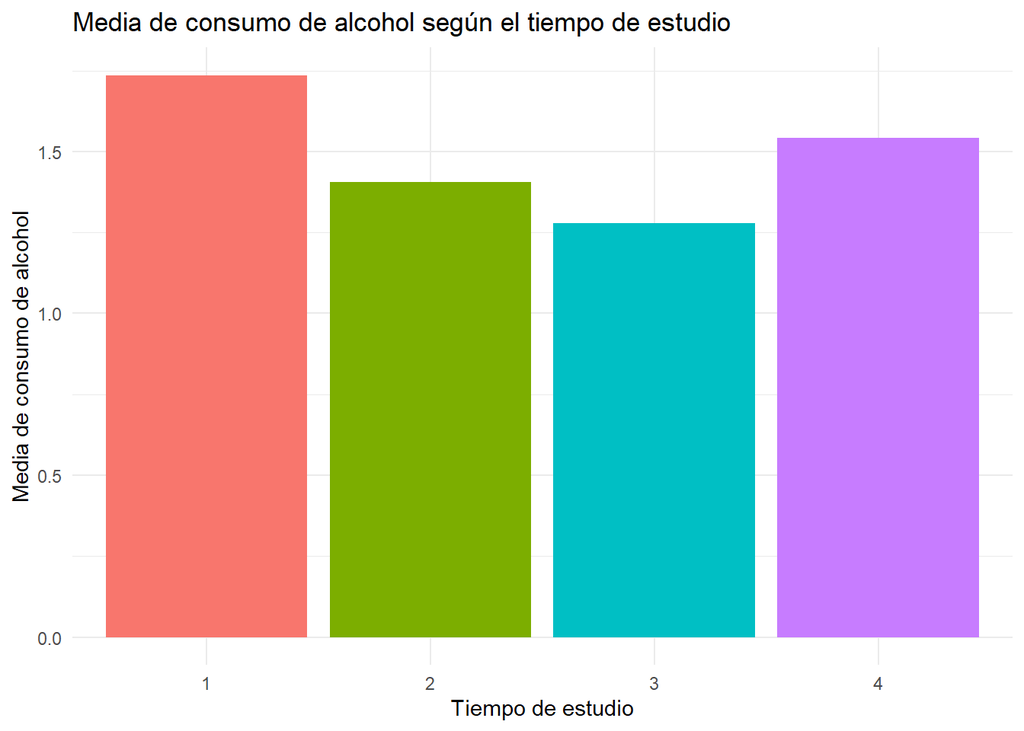

```r
df$studytime <- factor(df$studytime, levels = c("1", "2", "3", "4"))
df$Dalc <- as.numeric(as.character(df$Dalc)) # Si 'Dalc' es un factor, convertirlo a numérico

df_clean <- df %>%
  filter(!is.na(Dalc) & !is.na(studytime))

df_summary <- df_clean %>%
  group_by(studytime) %>%
  summarise(media_consumo = mean(Dalc, na.rm = TRUE))

ggplot(df_summary, aes(x = studytime, y = media_consumo, fill = studytime)) +
  geom_col(show.legend = FALSE) +
  labs(title = "Media de consumo de alcohol según el tiempo de estudio",
       x = "Tiempo de estudio",
       y = "Media de consumo de alcohol") +
  theme_minimal()
```

## Media de consumo de alcohol en función de si los padres están separados o no (entre semana y fin de semana)

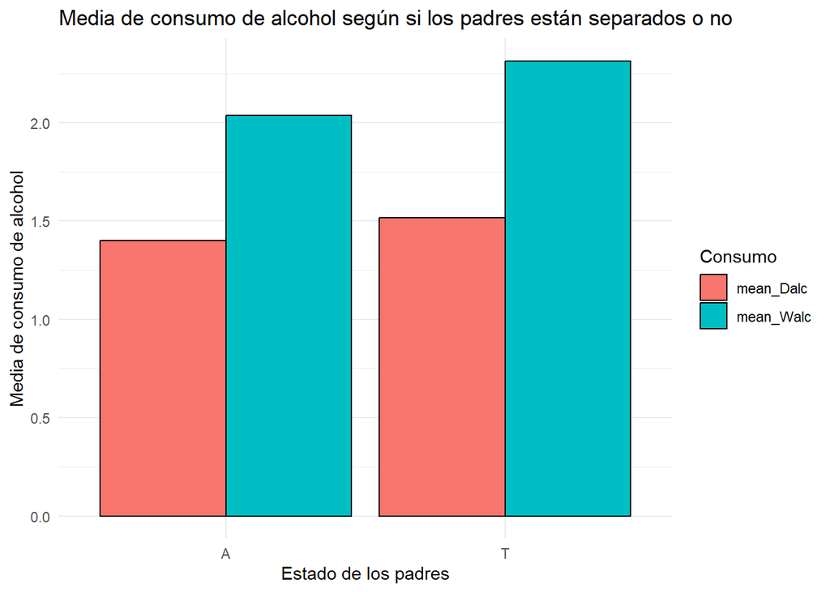

```r
df %>%
  group_by(Pstatus) %>%
  summarise(mean_Dalc = mean(Dalc), mean_Walc = mean(Walc)) %>%
  pivot_longer(cols = c(mean_Dalc, mean_Walc), names_to = "Consumo", values_to = "Media") %>%
  ggplot(aes(x = Pstatus, y = Media, fill = Consumo)) +
  geom_bar(stat = "identity", position = "dodge", color = "black") +
  labs(title = "Media de consumo de alcohol según si los padres están separados o no",
       x = "Estado de los padres",
       y = "Media de consumo de alcohol",
       fill = "Consumo") +
  theme_minimal()
```

## Media de consumo de alcohol según la relación familiar

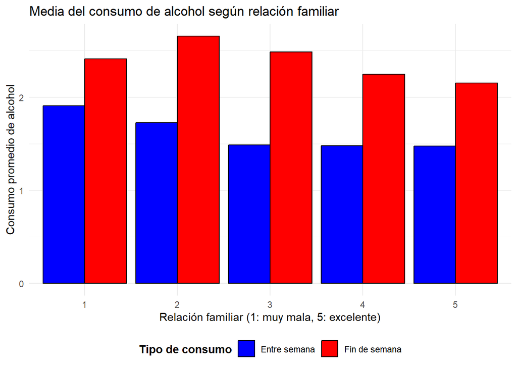

```r
famrel_consumption <- df %>%
  group_by(famrel) %>%
  summarise(
    avg_Dalc = mean(Dalc, na.rm = TRUE),
    avg_Walc = mean(Walc, na.rm = TRUE)
  ) %>%
  pivot_longer(cols = c(avg_Dalc, avg_Walc), names_to = "TipoConsumo", values_to = "MediaConsumo")

ggplot(famrel_consumption, aes(x = factor(famrel), y = MediaConsumo, fill = TipoConsumo)) +
  geom_bar(stat = "identity", position = "dodge", color = "black") +
  scale_fill_manual(values = c("avg_Dalc" = "blue", "avg_Walc" = "red"),
                    labels = c("Entre semana", "Fin de semana")) +
  labs(
    title = "Media del consumo de alcohol según relación familiar",
    x = "Relación familiar (1: muy mala, 5: excelente)",
    y = "Consumo promedio de alcohol",
    fill = "Tipo de consumo"
  ) +
  theme_minimal() +
  theme(
    legend.position = "bottom",
    legend.title = element_text(face = "bold"),
    strip.text = element_text(face = "bold")
  )
```

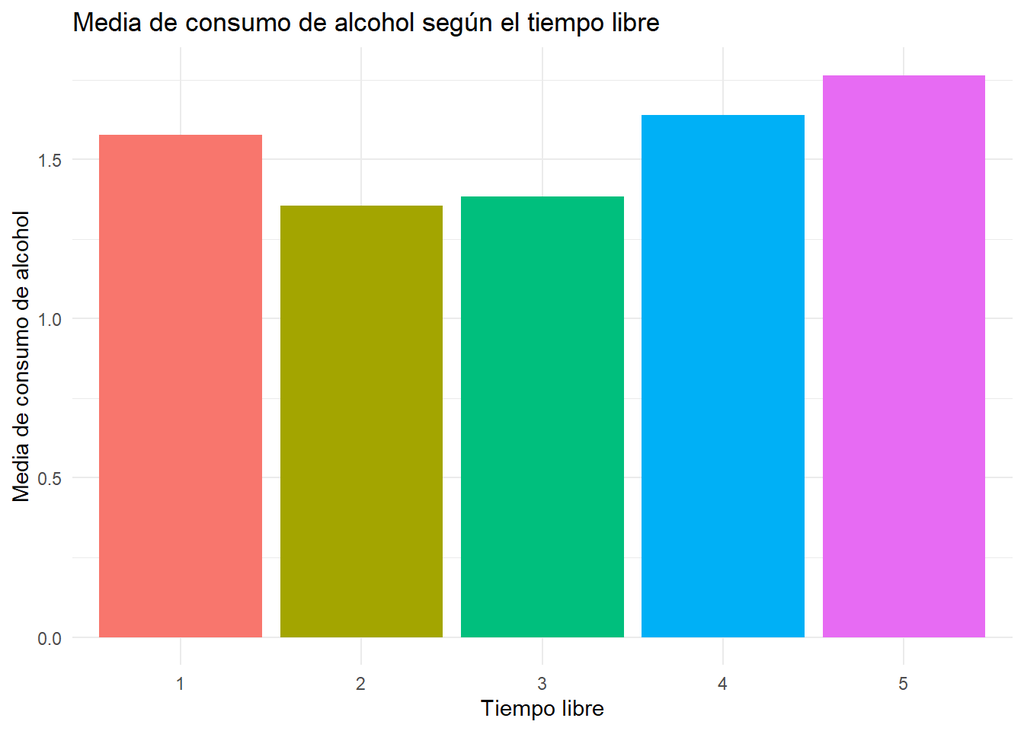

```r
df$freetime <- factor(df$freetime, levels = c("1", "2", "3", "4", "5"))
df$Dalc <- as.numeric(as.character(df$Dalc))  # Si 'Dalc' es un factor, convertirlo a numérico

df_clean <- df %>%
  filter(!is.na(Dalc) & !is.na(freetime))

df_summary_freetime <- df_clean %>%
  group_by(freetime) %>%
  summarise(media_consumo = mean(Dalc, na.rm = TRUE))

ggplot(df_summary_freetime, aes(x = freetime, y = media_consumo, fill = freetime)) +
  geom_col(show.legend = FALSE) +
  labs(title = "Media de consumo de alcohol según el tiempo libre",
       x = "Tiempo libre",
       y = "Media de consumo de alcohol") +
  theme_minimal()
```

## Consumo de alcohol en función de la frecuencia de salida (entre semana vs fin de semana)

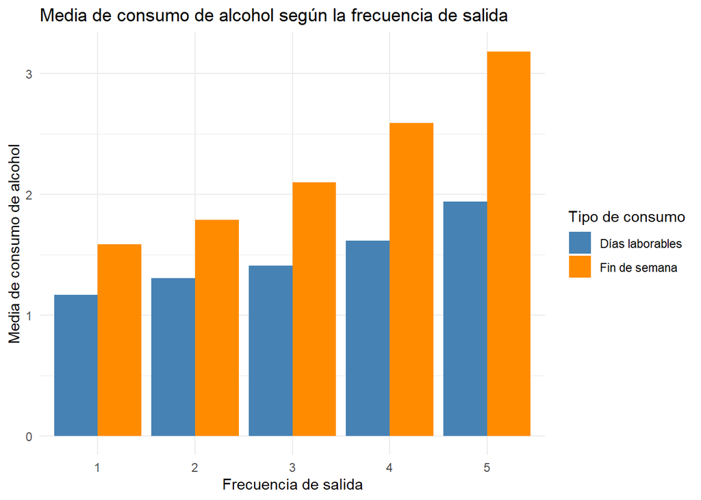

```r
df_summary <- df %>%
  group_by(goout) %>%
  summarise(
    average_consumption_dalc = mean(Dalc, na.rm = TRUE),
    average_consumption_walc = mean(Walc, na.rm = TRUE)
  )

df_long <- df_summary %>%
  pivot_longer(
    cols = c(average_consumption_dalc, average_consumption_walc),
    names_to = "type_of_consumption",
    values_to = "average_consumption"
  )

ggplot(df_long, aes(x = factor(goout), y = average_consumption, fill = type_of_consumption)) +
  geom_col(position = "dodge") +
  labs(
    title = "Media de consumo de alcohol según la frecuencia de salida",
    x = "Frecuencia de salida",
    y = "Media de consumo de alcohol",
    fill = "Tipo de consumo"
  ) +
  scale_fill_manual(
    values = c("average_consumption_dalc" = "steelblue",
               "average_consumption_walc" = "darkorange"),
    labels = c("average_consumption_dalc" = "Días laborables",
               "average_consumption_walc" = "Fin de semana")
  ) +
  theme_minimal()
```

## Media de consumo según la edad (entre semana vs fin de semana)

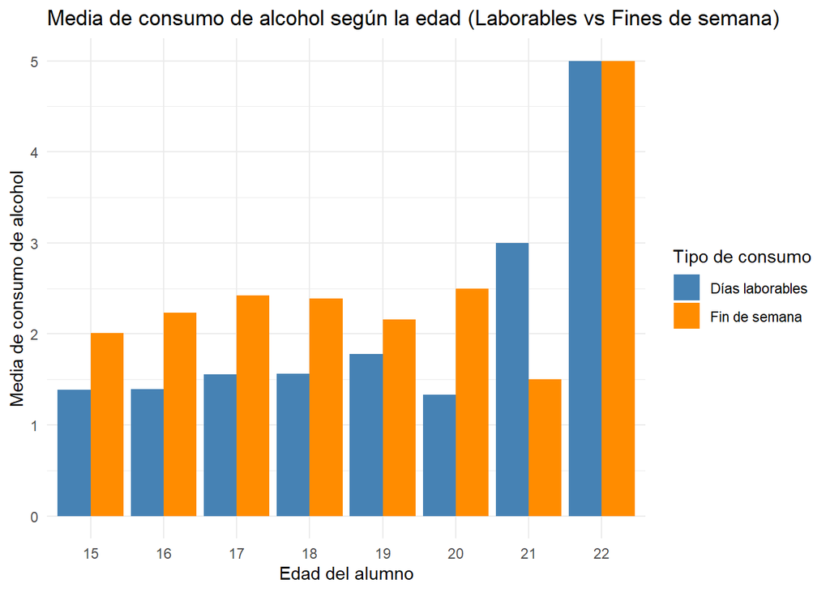

```r
df_summary <- df %>%
  group_by(age) %>%
  summarise(
    average_consumption_dalc = mean(Dalc, na.rm = TRUE),
    average_consumption_walc = mean(Walc, na.rm = TRUE)
  )

df_long <- df_summary %>%
  pivot_longer(
    cols = c(average_consumption_dalc, average_consumption_walc),
    names_to = "type_of_consumption",
    values_to = "average_consumption"
  )

ggplot(df_long, aes(x = factor(age), y = average_consumption, fill = type_of_consumption)) +
  geom_col(position = "dodge") +
  labs(
    title = "Media de consumo de alcohol según la edad (Laborables vs Fines de semana)",
    x = "Edad del alumno",
    y = "Media de consumo de alcohol",
    fill = "Tipo de consumo"
  ) +
  scale_fill_manual(
    values = c("average_consumption_dalc" = "steelblue",
               "average_consumption_walc" = "darkorange"),
    labels = c("average_consumption_dalc" = "Días laborables",
               "average_consumption_walc" = "Fin de semana")
  ) +
  theme_minimal()
```

## Media de consumo según el tiempo libre y el tiempo de estudio

```r
df_clean$Walc <- as.numeric(as.character(df_clean$Walc))
df_clean$Dalc <- as.numeric(as.character(df_clean$Dalc))

df_summary <- df_clean %>%
  group_by(studytime, freetime) %>%
  summarise(
    media_consumo_semanal = mean(Dalc, na.rm = TRUE),
    media_consumo_finsemana = mean(Walc, na.rm = TRUE)
  )
summary(df_summary$media_consumo_semanal)
```

```
##    Min. 1st Qu.  Median    Mean 3rd Qu.    Max.
##   1.000   1.324   1.512   1.539   1.708   2.250
```

```r
summary(df_summary$media_consumo_finsemana)
```

```
##    Min. 1st Qu.  Median    Mean 3rd Qu.    Max.
##   1.000   1.883   2.090   2.162   2.494   3.500
```

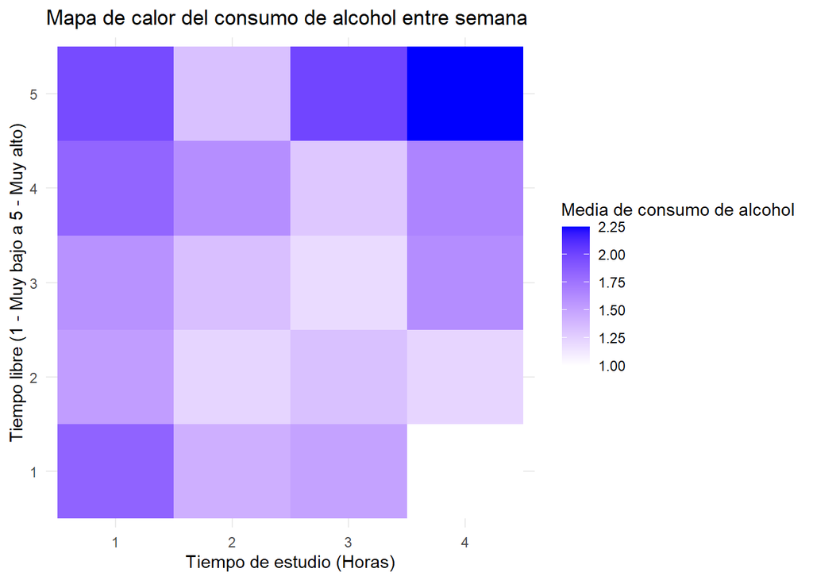

```r
# Mapa de calor para el consumo de alcohol entre semana (Dalc)
ggplot(df_summary, aes(x = studytime, y = freetime, fill = media_consumo_semanal)) +
  geom_tile() +
  labs(title = "Mapa de calor del consumo de alcohol entre semana",
       x = "Tiempo de estudio (Horas)",
       y = "Tiempo libre (1 - Muy bajo a 5 - Muy alto)",
       fill = "Media de consumo de alcohol") +
  scale_fill_gradient(low = "white", high = "blue") +
  theme_minimal()
```

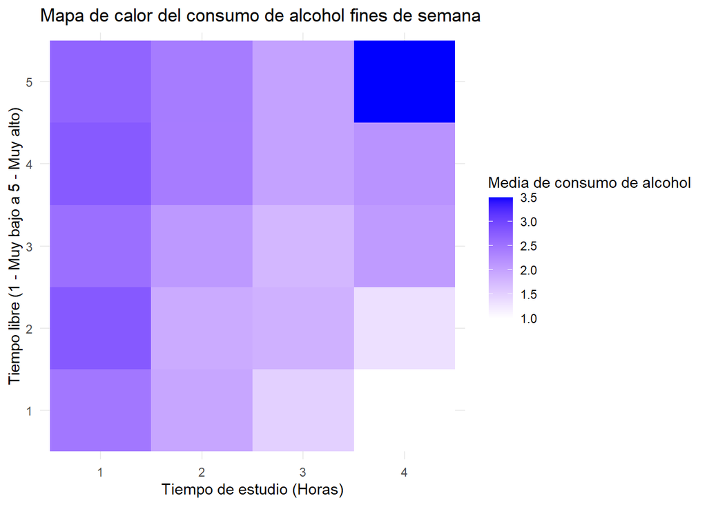

```r
# Mapa de calor para el consumo de alcohol fines de semana (Walc)
ggplot(df_summary, aes(x = studytime, y = freetime, fill = media_consumo_finsemana)) +
  geom_tile() +
  labs(title = "Mapa de calor del consumo de alcohol fines de semana",
       x = "Tiempo de estudio (Horas)",
       y = "Tiempo libre (1 - Muy bajo a 5 - Muy alto)",
       fill = "Media de consumo de alcohol") +
  scale_fill_gradient(low = "white", high = "blue") +
  theme_minimal()
```